# Computabilità, Complessità e Logica

Gabriele Granzotto

2022-11-10

## **Fac Simile Prima Provetta**

### **Esercizio 1**

Si scriva un automa regolare che riconosca il linguaggio $L_k \subseteq \{a,b\}^*$ tale che $L_k=\{w:|w|_a = k, |w|_b = pari\}$.

### **Svolgimento**

L’idea è quella di far fare $k$ transizioni di $a$ prima di arrivare allo stato finale e un numero pari di $b$ quindi ho creato due “binari”, su uno dei due ho messo lo stato iniziale e finale e per saltare all’altro binario si fa una transizione $b$ ma poi per poter essere accettata la parola deve necessariamente rifare una transizione $b$ sul primo binario, e da qui la parità.

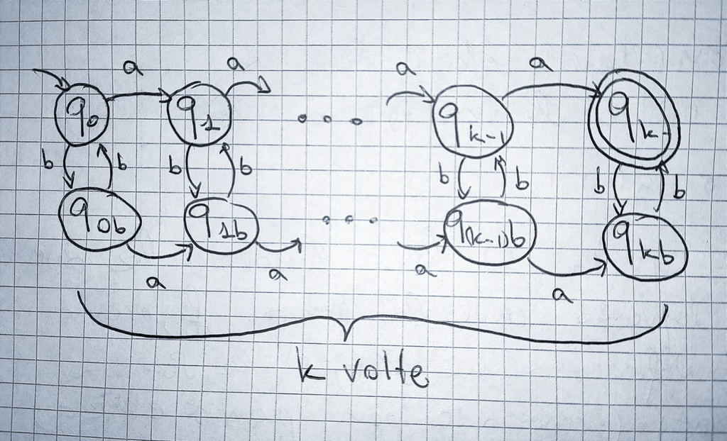

Automa_Allegato

### **Esercizio 2**

Si dimostri che il linguaggio $L \subseteq \{a,b\}^*$ tale che $L=\{w:|w|_a\leq|w|_b\}$ non è regolare.

### **Svolgimento**

Si dimostra attraverso il **Pumping Lemma**.

**Per Assurdo**
prendo un $w = aaabbbb$
prendo $p = 6$
$$x \cdot y \cdot z = a \cdot aab \cdot bbb$$
$$x = a, \quad y = aab \quad
\Rightarrow \quad |x \cdot y| = |aaab| = 4 \quad \Rightarrow \quad |x
\cdot y| < p$$
adesso allora studiamo il caso $a \cdot (aab)^i \cdot bbb$

per $i=2$
$$a(aab)(aab)bbb$$
$$|w|_a = 5; \quad |w|_b = 5$$
per $i=3$
$$a(aab)(aab)(aab)bbb$$
$$|w|_a = 7;
\quad |w|_b = 6$$
$$Contraddizione!
\quad \blacksquare$$

### **Esercizio 3**

Si consideri la grammatica libera dal contesto con le seguenti regole:
$$S \rightarrow ABC$$
$$B \rightarrow HG$$
$$H \rightarrow H$$
$$G \rightarrow g$$
$$A \rightarrow A$$
$$A \rightarrow H$$
$$A \rightarrow a$$
$$B \rightarrow W$$
$$W \rightarrow w$$

(le lettere maiuscole non sono simboli terminali e le lettere minuscole sono simboli terminali). Si verifichi se $L(G)=\emptyset$ o se $L(G)\neq\emptyset$.

### **Svolgimento**

All’esercizio si applica questo metodo di svolgimento:

- si scrivono tutti i simboli una singola volta partendo da $S$ e arrivando ai simboli terminali:

$$SABCHGWgaw$$

- si segnano i simboli terminali:

$$SABCHGW\bar g \bar a \bar w$$

- si segna ogni simbolo che ha tutti i simboli a destra della relazione segnati:

$$S \bar A \bar B C H \bar G \bar W \bar
g \bar a \bar w$$

- se anche $S$ risulterà segnata allora potremo dire che c’è almeno una parola **accettata**
- sennò si può dire che $L(G)=\emptyset$

In questo caso il linguaggio della grammatica è vuoto.

### **Esercizio 4**

Si scriva una MdT $M$ che accetta il linguaggio $L = \{ w \cdot w^R : w \in \{a,b\}^*\}$ ($w^R$ è la parola speculare di $w$).

### **Svolgimento**

Il metodo risolutivo adottato per questo problema è il seguente:

- uso due nastri, la $MdT$ non cambia di espressività;
- scrivo sul primo nastro la parola in input, ossia sia $w$ che $w'$ che noi dobbiamo dimostrare essere $w^R$;
- ricopio la parola ma all’incontrario sul secondo nastro;
- passo i due nastri cella per cella e controllo siano uguali;
- mi fermo alla prima differenza tra i due nastri;
- se arrivo alla fine senza essermi fermato vuol dire che sono uguali e quindi **accetto**, altrimenti **rifiuto** prima;

Da notare che ho adottato la possibilità che un nastro possa, oltre che andare a destra e sinistra ($L$ o $R$), stare fermo ($S$).  
In più è da notare che si accetta anche il caso degenere dove la parola $w$ è degenere, e quindi il caso è banale.

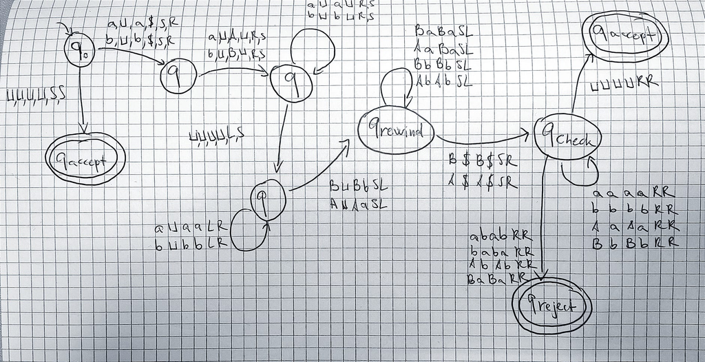

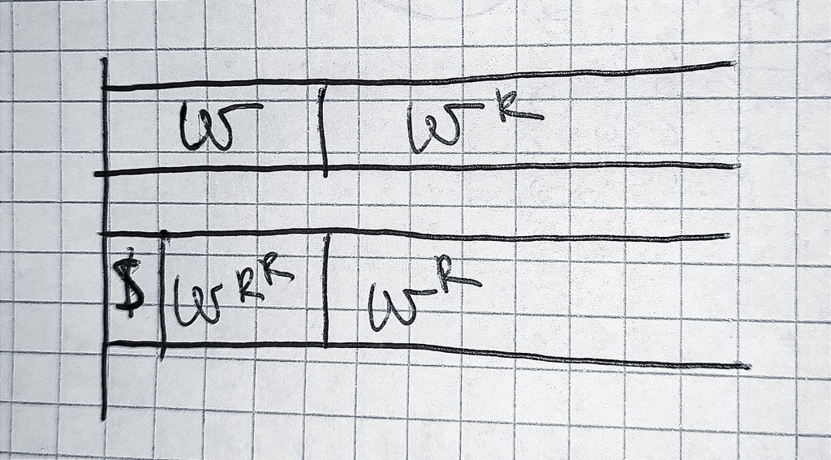

### **Esercizio 5**

Si supponga che $f$ e $g$ siano due funzioni computabili. Si scriva ad alto livello una macchina di Turing $M$ che computa la funzione $f \circ g$.

### **Svolgimento**

Si può partire dal fatto che le due funzioni $f$,$g$ possono essere viste come $MdT$ computabili e quindi con un risultato garantito.  
Quindi l’idea generale è di costruire una $MdT_U$ Macchina di Turing Universale fatta da 3 nastri, dove:

- sul primo viene scritto in sequenza la codifica di $f$, quella di $g$ e la parola $w$;
- il nastro successivo viene riempito dalla codifica di $f$ e da il futuro output del primo nastro, ossia $g(w)$;
- sul terzo nastro verrà scritto l’output del secondo nastro, ossia $f(g(w))$ che è anche ciò che volevamo.

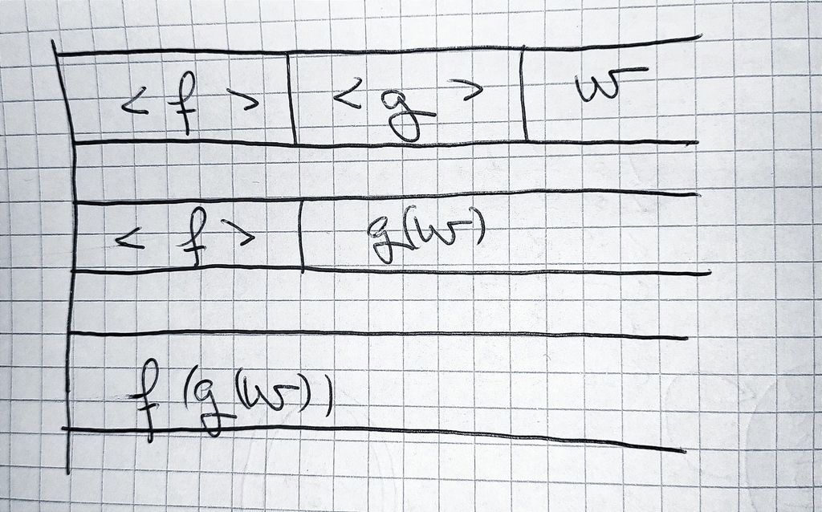

nastri MdT

Procedimento:

```
BEGIN
  applico la MdT g alla parola w
  ottengo l'output g(w)
  copio <f> e g(w) sul secondo nastro
  applico la MdT f alla parola g(w)
  ottengo l'output f(g(w))
  copio f(g(w)) sul terzo nastro
END
```